# Reproducible Research: Peer Assessment 1

## Loading and preprocessing the data

Load data corresponding to data from a device that collects data at 5 minute intervals through out the day. The data consists of two months of data from an anonymous individual collected during the months of October and November, 2012 and include the number of steps taken in 5 minute intervals each day.

This script assumes that the data file, “activity.csv” is present and unzipped in the same directory as the script. Prior to executing the code, the user should set the working directory to the correct directory.

```r
# Load libraries used in the script
library(plyr)
# Store the default graphical parameters in case we need them
old.par <- par()

# Read in the data file, specifying steps as a number, date as a factor, and interval as a factor
data <- read.csv("activity.csv", header=T, colClasses = c("numeric", "factor", "factor"))
```

## What is mean total number of steps taken per day?

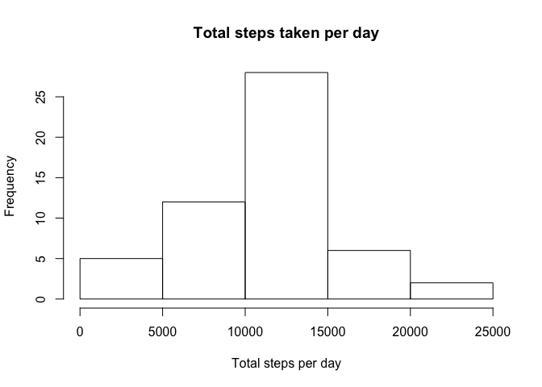

```r
# Use plyr summarise function to sum the number of steps taken on each day
daySteps <- ddply(data, c("date"), summarise, stepsPerDay = sum(steps))

# Generate a histogram of the number of steps taken per day
hist(daySteps$stepsPerDay, xlab="Total steps per day", ylab="Frequency", main="Total steps taken per day")
```

```r
# Calculate the average steps per day, removing NAs
meanStepsPerDay <- mean(daySteps$stepsPerDay, na.rm=T)
medianStepsPerDay <- median(daySteps$stepsPerDay, na.rm=T)

# Echo the results to the screen
meanStepsPerDay
```

```
## [1] 10766.19
```

```r
medianStepsPerDay
```

```
## [1] 10765
```

## What is the average daily activity pattern?

Calculate and display the average steps for any given 5 minute interval using a line graph

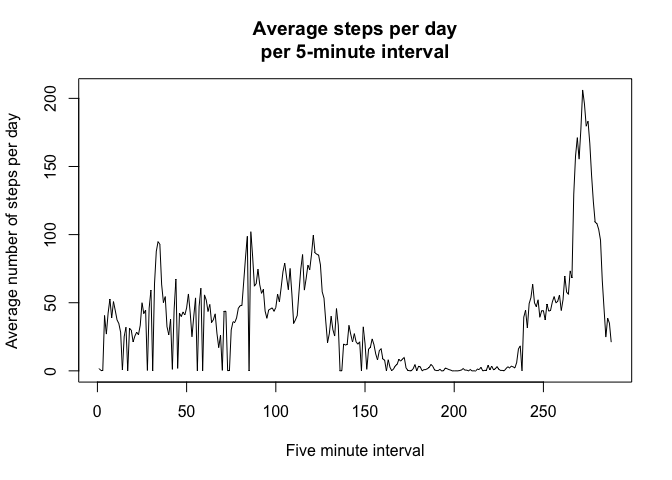

```r
# Create a new dataframe that contains the mean steps per day for each interval
intervalSteps <- ddply(data, c("interval"), summarise, stepsPerInterval = mean(steps, na.rm=T))

# Recast the interval value as a numeric value so that the graph puts things normally
intervalSteps$interval <- as.numeric(intervalSteps$interval)

# Make a line graph that shows things for each interval
plot(as.numeric(intervalSteps$interval), intervalSteps$stepsPerInterval, type="l", pch=".", xlab="Five minute interval", ylab="Average number of steps per day", main="Average steps per day\nper 5-minute interval")
```

```r
# Identify the interval that contains the maximum number of steps per interval
maxInterval <- intervalSteps$interval[which(intervalSteps$stepsPerInterval == max(intervalSteps$stepsPerInterval))]
maxInterval
```

```
## [1] 272
```